# Assignment 9

Mason

2023-03-21

## Assignment 9 R Markdown

This is the Markdown page for Assignment 9. We are looking at grad school admissions data and making some predictions. Before starting, gotta load packages and load in the data.

```r
library(tidyverse)
library(modelr)
library(easystats)

df <- read_csv("../../Data/GradSchool_Admissions.csv")
```

## Creating Models

To start off, the response variable needs to be converted into binomial form.

```r
df <- df %>%
  mutate(admit = case_when(admit == 1 ~ TRUE,
                              TRUE ~ FALSE))
```

This allows us to create a logistic regression. Now to create models and see how they compare with each other.

```r
mod1 <- glm(data = df,
            formula = admit ~ gpa + gre + rank,
            family = "binomial")

mod2 <- glm(data = df,
            formula = admit ~ gpa * gre * rank,
            family = "binomial")

mod3 <- glm(data = df,
            formula = admit ~ (gpa + gre) * rank,
            family = "binomial")

mod4 <- glm(data = df,
            formula = admit ~ (gpa * gre) + rank,
            family = "binomial")

compare_performance(mod1,mod2,mod3,mod4)
```

```
## # Comparison of Model Performance Indices
##
## Name | Model | AIC (weights) | AICc (weights) | BIC (weights) | Tjur's R2 |  RMSE | Sigma | Log_loss | Score_log | Score_spherical |   PCP
## ------------------------------------------------------------------------------------------------------------------------------------------
## mod1 |   glm | 467.4 (0.362) |  467.5 (0.370) | 483.4 (0.826) |     0.099 | 0.442 | 1.077 |    0.574 |   -50.496 |           0.004 | 0.609
## mod2 |   glm | 472.2 (0.033) |  472.6 (0.029) | 504.2 (<.001) |     0.106 | 0.440 | 1.079 |    0.570 |   -50.593 |           0.005 | 0.613
## mod3 |   glm | 471.3 (0.052) |  471.5 (0.050) | 495.3 (0.002) |     0.100 | 0.442 | 1.080 |    0.574 |   -50.582 |           0.005 | 0.610
## mod4 |   glm | 466.6 (0.553) |  466.7 (0.550) | 486.6 (0.171) |     0.105 | 0.440 | 1.075 |    0.571 |   -50.481 |           0.004 | 0.612
```

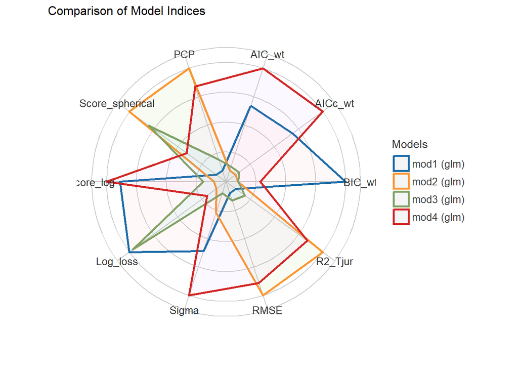

```r
compare_performance(mod1,mod2,mod3,mod4) %>% plot
```

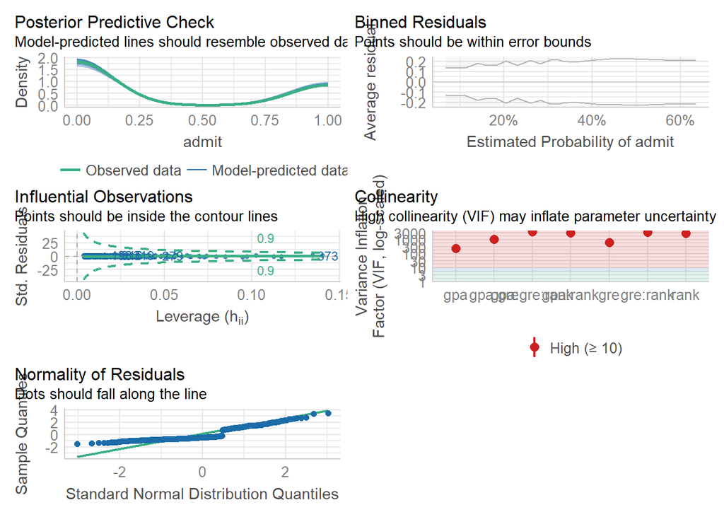

```r
check_model(mod2)
```

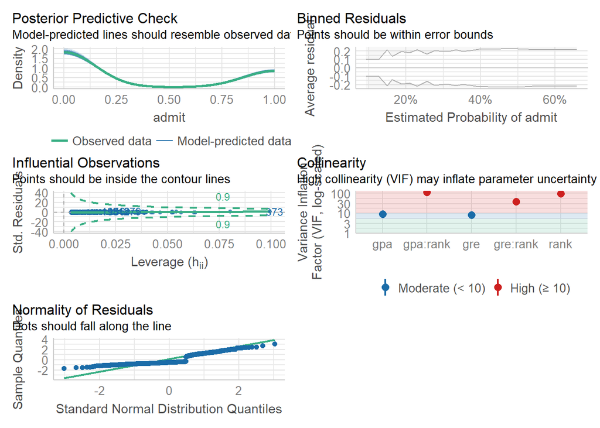

```r
check_model(mod3)
```

```r
pred <- add_predictions(df,mod3, type="response")
```

Now we can plot our predictions!

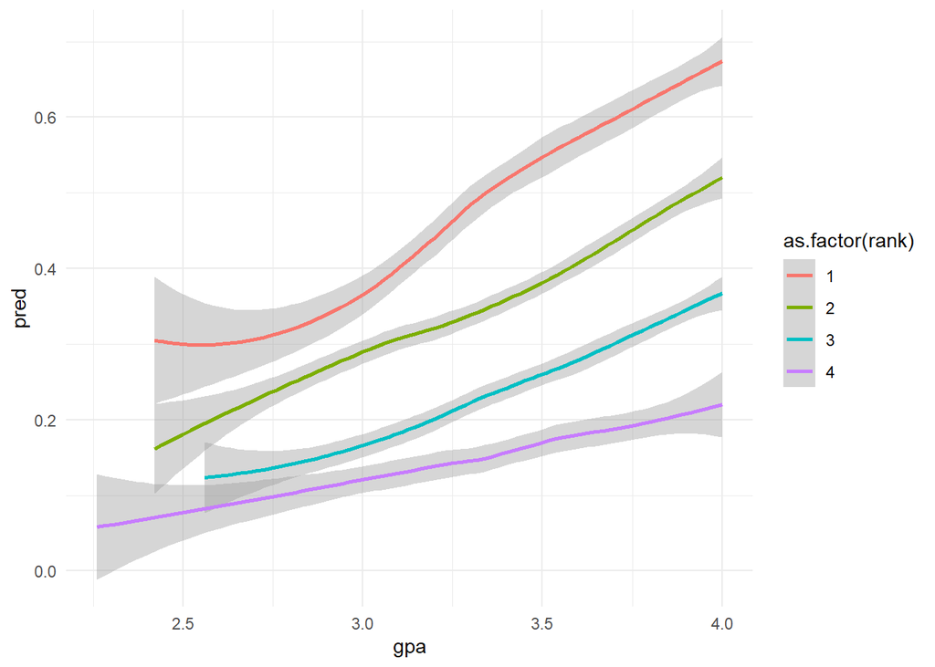

```r
pred %>%
  ggplot(aes(x=gpa,y=pred, color = as.factor(rank))) +
  geom_smooth()+
  theme_minimal()
```

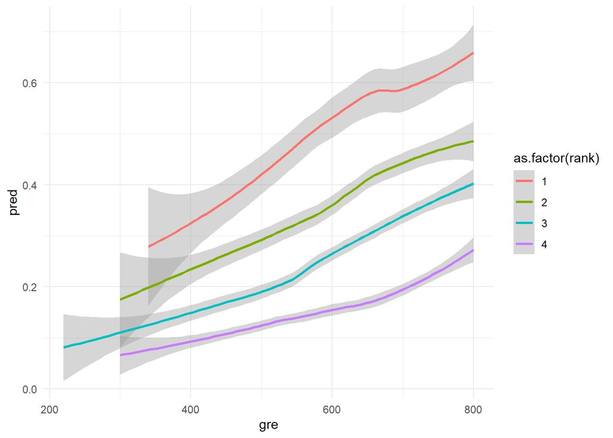

```r
pred %>%
  ggplot(aes(x=gre,y=pred, color = as.factor(rank))) +
  geom_smooth()+
  theme_minimal()
```

Cool, what about predicting with a new data set? I wonder how I would stack up for acceptance? I haven’t taken a GRE so I put a random, lower than mean score. I also don’t know what rank UVU is, but I think I remember from class that is was either 3 or 4, so lets see both.

```r
mason <- data.frame(gre = 500,gpa = 3.55,rank = 3)

add_predictions(mason,mod3,type="response")
```

```
##   gre  gpa rank      pred
## 1 500 3.55    3 0.2234554
```

```r
mason2 <- data.frame(gre = 500,gpa = 3.55,rank = 4)

add_predictions(mason2,mod3,type="response")
```

```
##   gre  gpa rank      pred
## 1 500 3.55    4 0.1372942
```

Ouch. I know this is just a model and all models are wrong but ouch. ~ 13% to ~ 22%, depending on what rank UVU is. I wonder how having a slightly better than average GRE would affect my predicted acceptance rate?

```r
mason3 <- data.frame(gre = 600,gpa = 3.55,rank = 3)

add_predictions(mason3,mod3,type="response")
```

```
##   gre  gpa rank      pred
## 1 600 3.55    3 0.2680649
```

```r
mason4 <- data.frame(gre = 600,gpa = 3.55,rank = 4)

add_predictions(mason4,mod3,type="response")
```

```
##   gre  gpa rank     pred
## 1 600 3.55    4 0.170778
```